# Задания

1. Посчитайте, сколько книг вышло после 1 января 2000 года;
2. Для каждой книги посчитайте количество обзоров и среднюю оценку;
3. Определите издательство, которое выпустило наибольшее число книг толще 50 страниц — так вы исключите из анализа брошюры;
4. Определите автора с самой высокой средней оценкой книг — учитывайте только книги с 50 и более оценками;
5. Посчитайте среднее количество обзоров от пользователей, которые поставили больше 48 оценок;
6. Выведите таблицу, которая будет содержать по году публикации:
- количество издательств,
- выпущенных книг,
- сколько всего тысяч страниц было в изданных книгах

(отобразить только те года, в которых издано более 30 книг); 7. Выведите топ семь пользователей по суммарному показателю написанных ревью и поставленных оценок, указывая суммарное количество страниц в книгах, на которые они отреагировали.

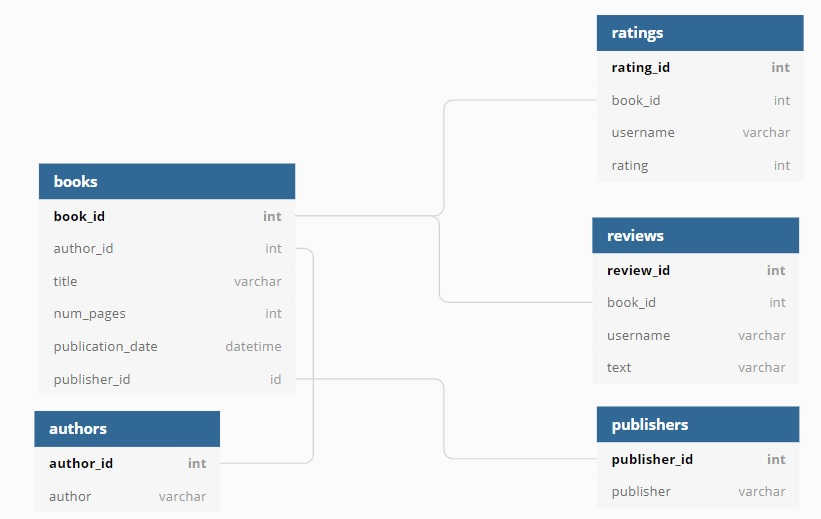

## Организуем доступ к базе данных. Подгрузим данные и ознакомимся с ними.

```python
# импортируем необходимые библиотеки
import pandas as pd
import sqlalchemy as sa
```

```python
# устанавливаем параметры
db_config = {
            'user': 'praktikum_student', # имя пользователя
            'pwd': 'Sdf4$2;d-d30pp', # пароль
            'host': 'rc1b-wcoijxj3yxfsf3fs.mdb.yandexcloud.net',
            'port': 6432, # порт подключения
            'db': 'data-analyst-final-project-db' # название базы данных
            }
connection_string = 'postgresql://{user}:{pwd}@{host}:{port}/{db}'.format(**db_config)

# сохраняем коннектор
engine = sa.create_engine(connection_string, connect_args={'sslmode':'require'})
```

```python
# чтобы выполнить SQL-запрос, пишем функцию с использованием Pandas
def get_sql_data(query:str, engine:sa.engine.base.Engine=engine) -> pd.DataFrame:
    '''Открываем соединение, получаем данные из sql, закрываем соединение'''
    with engine.connect() as con:
        return pd.read_sql(sql=sa.text(query), con = con)
```

```python
for table in ['books', 'authors', 'publishers', 'ratings', 'reviews']:
    query = '''
    SELECT *
    FROM {}
            '''.format(table)

    req = pd.io.sql.read_sql(query, con = engine)
    display(req.info(), req.head(4), 'Количество строк:', len(req), ('*'*50))
```

```
<class 'pandas.core.frame.DataFrame'>
RangeIndex: 1000 entries, 0 to 999
Data columns (total 6 columns):
 #   Column            Non-Null Count  Dtype
---  ------            --------------  -----
 0   book_id           1000 non-null   int64
 1   author_id         1000 non-null   int64
 2   title             1000 non-null   object
 3   num_pages         1000 non-null   int64
 4   publication_date  1000 non-null   object
 5   publisher_id      1000 non-null   int64
dtypes: int64(4), object(2)
memory usage: 47.0+ KB
```

```
None
```

|  | book_id | author_id | title | num_pages | publication_date | publisher_id |
| --- | --- | --- | --- | --- | --- | --- |
| 0 | 1 | 546 | 'Salem's Lot | 594 | 2005-11-01 | 93 |
| 1 | 2 | 465 | 1 000 Places to See Before You Die | 992 | 2003-05-22 | 336 |
| 2 | 3 | 407 | 13 Little Blue Envelopes (Little Blue Envelope... | 322 | 2010-12-21 | 135 |
| 3 | 4 | 82 | 1491: New Revelations of the Americas Before C... | 541 | 2006-10-10 | 309 |

```
'Количество строк:'
```

```
1000
```

```
'**************************************************'
```

```
<class 'pandas.core.frame.DataFrame'>
RangeIndex: 636 entries, 0 to 635
Data columns (total 2 columns):
 #   Column     Non-Null Count  Dtype
---  ------     --------------  -----
 0   author_id  636 non-null    int64
 1   author     636 non-null    object
dtypes: int64(1), object(1)
memory usage: 10.1+ KB
```

```
None
```

|  | author_id | author |
| --- | --- | --- |
| 0 | 1 | A.S. Byatt |
| 1 | 2 | Aesop/Laura Harris/Laura Gibbs |
| 2 | 3 | Agatha Christie |
| 3 | 4 | Alan Brennert |

```
'Количество строк:'
```

```
636
```

```
'**************************************************'
```

```
<class 'pandas.core.frame.DataFrame'>
RangeIndex: 340 entries, 0 to 339
Data columns (total 2 columns):
 #   Column        Non-Null Count  Dtype
---  ------        --------------  -----
 0   publisher_id  340 non-null    int64
 1   publisher     340 non-null    object
dtypes: int64(1), object(1)
memory usage: 5.4+ KB
```

```
None
```

|  | publisher_id | publisher |
| --- | --- | --- |
| 0 | 1 | Ace |
| 1 | 2 | Ace Book |
| 2 | 3 | Ace Books |
| 3 | 4 | Ace Hardcover |

```
'Количество строк:'
```

```
340
```

```
'**************************************************'
```

```
<class 'pandas.core.frame.DataFrame'>
RangeIndex: 6456 entries, 0 to 6455
Data columns (total 4 columns):
 #   Column     Non-Null Count  Dtype
---  ------     --------------  -----
 0   rating_id  6456 non-null   int64
 1   book_id    6456 non-null   int64
 2   username   6456 non-null   object
 3   rating     6456 non-null   int64
dtypes: int64(3), object(1)
memory usage: 201.9+ KB
```

```
None
```

|  | rating_id | book_id | username | rating |
| --- | --- | --- | --- | --- |
| 0 | 1 | 1 | ryanfranco | 4 |
| 1 | 2 | 1 | grantpatricia | 2 |
| 2 | 3 | 1 | brandtandrea | 5 |
| 3 | 4 | 2 | lorichen | 3 |

```
'Количество строк:'
```

```
6456
```

```
'**************************************************'
```

```
<class 'pandas.core.frame.DataFrame'>
RangeIndex: 2793 entries, 0 to 2792
Data columns (total 4 columns):
 #   Column     Non-Null Count  Dtype
---  ------     --------------  -----
 0   review_id  2793 non-null   int64
 1   book_id    2793 non-null   int64
 2   username   2793 non-null   object
 3   text       2793 non-null   object
dtypes: int64(2), object(2)
memory usage: 87.4+ KB
```

```
None
```

|  | review_id | book_id | username | text |
| --- | --- | --- | --- | --- |
| 0 | 1 | 1 | brandtandrea | Mention society tell send professor analysis. ... |
| 1 | 2 | 1 | ryanfranco | Foot glass pretty audience hit themselves. Amo... |
| 2 | 3 | 2 | lorichen | Listen treat keep worry. Miss husband tax but ... |
| 3 | 4 | 3 | johnsonamanda | Finally month interesting blue could nature cu... |

```
'Количество строк:'
```

```
2793
```

```
'**************************************************'
```

**Выводы:**

- Таблицы выводятся корректно;
- Пропуски отсутствуют, типы данных корректны.
- Количество строк в таблицах:
  - books - 1000
  - authors - 636
  - publishers - 340
  - ratings - 6456
  - reviews - 2793

## Выполним задания.

### Посчитайте, сколько книг вышло после 1 января 2000 года;

```python
books_cnt = '''

SELECT COUNT(book_id) AS books_cnt
FROM books
WHERE publication_date >= '2000-01-02'

'''
get_sql_data(books_cnt)
```

|  | books_cnt |
| --- | --- |
| 0 | 819 |

**Вывод:**

После 1 января 2000 года вышло 819 книг.

### Для каждой книги посчитайте количество обзоров и среднюю оценку;

```python
reviews_rating = '''

SELECT b.title AS title,
       b.book_id AS id,
       AVG(r.rating) AS avg_rate,
       COUNT(DISTINCT rev.text) AS cnt_reviews
FROM   books AS b
INNER JOIN ratings AS r ON r.book_id = b.book_id
LEFT JOIN reviews AS rev ON rev.book_id = b.book_id
GROUP BY b.title,
         b.book_id
ORDER BY COUNT(DISTINCT rev.text) DESC
'''

get_sql_data(reviews_rating)
```

|  | title | id | avg_rate | cnt_reviews |
| --- | --- | --- | --- | --- |
| 0 | Twilight (Twilight #1) | 948 | 3.662500 | 7 |
| 1 | Water for Elephants | 963 | 3.977273 | 6 |
| 2 | The Glass Castle | 734 | 4.206897 | 6 |
| 3 | Harry Potter and the Prisoner of Azkaban (Harr... | 302 | 4.414634 | 6 |
| 4 | The Curious Incident of the Dog in the Night-Time | 695 | 4.081081 | 6 |
| ... | ... | ... | ... | ... |
| 995 | Anne Rice's The Vampire Lestat: A Graphic Novel | 83 | 3.666667 | 0 |
| 996 | The Natural Way to Draw | 808 | 3.000000 | 0 |
| 997 | The Cat in the Hat and Other Dr. Seuss Favorites | 672 | 5.000000 | 0 |
| 998 | Essential Tales and Poems | 221 | 4.000000 | 0 |
| 999 | Disney's Beauty and the Beast (A Little Golden... | 191 | 4.000000 | 0 |

1000 rows × 4 columns

### Определите издательство, которое выпустило наибольшее число книг толще 50 страниц — так вы исключите из анализа брошюры;

```python
publisher = '''

SELECT publisher,
       COUNT(book_id) AS books_count
FROM publishers as p
JOIN books AS b ON p.publisher_id = b.publisher_id
WHERE num_pages > 50
GROUP BY publisher
ORDER BY books_count DESC
'''

get_sql_data(publisher)
```

|  | publisher | books_count |
| --- | --- | --- |
| 0 | Penguin Books | 42 |
| 1 | Vintage | 31 |
| 2 | Grand Central Publishing | 25 |
| 3 | Penguin Classics | 24 |
| 4 | Ballantine Books | 19 |
| ... | ... | ... |
| 329 | Turtleback | 1 |
| 330 | Atheneum Books for Young Readers: Richard Jack... | 1 |
| 331 | Penguin Signet | 1 |
| 332 | Victor Gollancz | 1 |
| 333 | Harvard Business Review Press | 1 |

334 rows × 2 columns

**Вывод:**

Издательство с наибольшим количеством выпущенных книг (толще 50 страниц) - Penguin Books. Количество книг - 42 штуки.

### Определите автора с самой высокой средней оценкой книг — учитывайте только книги с 50 и более оценками;

```python
authors = '''

SELECT author AS name_author,
       AVG(rating) AS avg_rating
FROM
    (SELECT author_id,
            AVG(rating) AS rating
     FROM books as b
     JOIN ratings as r ON b.book_id = r.book_id
     GROUP BY author_id,
              title
     HAVING COUNT(title) >= 50) AS req
JOIN authors AS a ON req.author_id = a.author_id
GROUP BY name_author
ORDER BY avg_rating DESC
'''

get_sql_data(authors)
```

|  | name_author | avg_rating |
| --- | --- | --- |
| 0 | J.K. Rowling/Mary GrandPré | 4.283844 |
| 1 | Markus Zusak/Cao Xuân Việt Khương | 4.264151 |
| 2 | J.R.R. Tolkien | 4.258446 |
| 3 | Louisa May Alcott | 4.192308 |
| 4 | Arthur Golden | 4.107143 |
| 5 | Rick Riordan | 4.080645 |
| 6 | William Golding | 3.901408 |
| 7 | J.D. Salinger | 3.825581 |
| 8 | Paulo Coelho/Alan R. Clarke/Özdemir İnce | 3.789474 |
| 9 | William Shakespeare/Paul Werstine/Barbara A. M... | 3.787879 |
| 10 | Dan Brown | 3.754540 |
| 11 | Lois Lowry | 3.750000 |
| 12 | George Orwell/Boris Grabnar/Peter Škerl | 3.729730 |
| 13 | Stephenie Meyer | 3.662500 |
| 14 | John Steinbeck | 3.622951 |

**Вывод:**

Среди книг, получившиших 50 и более оценок, автор с самой высокой средней оценкой книг - J.K. Rowling/Mary GrandPré, средний рейтинг - 4.28.

### Посчитайте среднее количество обзоров от пользователей, которые поставили больше 48 оценок.

```python
users = '''

SELECT ROUND(AVG(count))
FROM
    (SELECT COUNT(text)
     FROM reviews
     FULL OUTER JOIN (SELECT username,
                      COUNT(rating_id) as cnt_rat
                      FROM ratings
                      GROUP BY username) AS cnt_rating
     ON cnt_rating.username = reviews.username
     where cnt_rat > 48
     GROUP BY reviews.username) AS cnt

'''

get_sql_data(users)
```

|  | round |
| --- | --- |
| 0 | 24.0 |

**Вывод:**

Среднее количество обзоров от пользователей, которые поставили больше 48 оценок составляет 24 обзора.

### Выведите таблицу, которая будет содержать по году публикации:

- количество издательств,
- выпущенных книг,
- сколько всего тысяч страниц было в изданных книгах

(отобразить только те года, в которых издано более 30 книг)

```python
years = '''

SELECT EXTRACT(YEAR FROM CAST(publication_date AS timestamp)) AS year,
       COUNT(DISTINCT publisher_id) AS publishers_cnt,
       COUNT(book_id) AS books_cnt,
       SUM(num_pages) AS num_pages_all
FROM books
GROUP BY year
HAVING COUNT(book_id) > 30
ORDER BY year DESC
'''

get_sql_data(years)
```

|  | year | publishers_cnt | books_cnt | num_pages_all |
| --- | --- | --- | --- | --- |
| 0 | 2007.0 | 38 | 50 | 18258 |
| 1 | 2006.0 | 109 | 184 | 68302 |
| 2 | 2005.0 | 89 | 139 | 55967 |
| 3 | 2004.0 | 88 | 124 | 46779 |
| 4 | 2003.0 | 65 | 105 | 41423 |
| 5 | 2002.0 | 62 | 94 | 38597 |
| 6 | 2001.0 | 41 | 60 | 21758 |
| 7 | 2000.0 | 35 | 38 | 13328 |
| 8 | 1999.0 | 26 | 41 | 15763 |

**Вывод:**

Больше 30 книг в год издавалось в период с 1999 по 2007 год. Самый пиковый год по рассматриваемым показателям - 2006.

### Выведите топ семь пользователей по суммарному показателю написанных ревью и поставленных оценок, указывая суммарное количество страниц в книгах, на которые они отреагировали

```python
top7 = '''

WITH
users_pages AS
  (SELECT username,
          SUM(num_pages) AS pages_all
   FROM
     (SELECT username,
             book_id
      FROM reviews
      UNION
      SELECT username,
             book_id
             FROM ratings) AS users
    LEFT JOIN books as b ON users.book_id = b.book_id
    GROUP BY username),

users_rat_rev AS
(SELECT rev.username,
        COUNT(DISTINCT review_id) AS reviews_cnt,
        COUNT(DISTINCT rating_id) AS ratings_cnt
 FROM reviews AS rev
 JOIN ratings AS rat ON rev.username = rat.username
 GROUP BY rev.username)

SELECT up.username,
       reviews_cnt,
       ratings_cnt,
       pages_all

FROM users_pages AS up
JOIN users_rat_rev AS urr ON up.username = urr.username
ORDER BY reviews_cnt DESC, ratings_cnt DESC
LIMIT 7
'''

get_sql_data(top7)
```

|  | username | reviews_cnt | ratings_cnt | pages_all |
| --- | --- | --- | --- | --- |
| 0 | susan85 | 29 | 49 | 19266 |
| 1 | sfitzgerald | 28 | 55 | 20938 |
| 2 | martinadam | 27 | 56 | 21213 |
| 3 | richard89 | 26 | 55 | 21013 |
| 4 | lesliegibbs | 26 | 50 | 18113 |
| 5 | tanya01 | 26 | 44 | 17522 |
| 6 | eallen | 26 | 40 | 16051 |

**Вывод:**

По количеству написанных ревью лидирует пользователь susan85 - 29, однако количество оценок, которая она оставила не самое высокое в топ-7.